# Sesssion 2

[figure not shown]

## Image thresholding

Thresholding is the process by which we create masks in opencv. Mask are imges which has only 2 colors white and black. We are going to look two thresholding funcions

1. `cv2.threshold`
2. `cv2.adaptiveThreshold`

**Note : For thresholding to work we need gray scale images**

### 1) `cv2.threshold`

This fucnion takes in 4 arguments. `cv2.threshold(image array, threshold value, max value, Threshold Type)`

- **Threshold value** - If pixel value is greater than the threshold value, it is assigned one value (may be white), else it is assigned another value (may be black).
- **max value** - The value assigned to the pixel whcih is greater than the threshold
- **Threshold Type** - There are 5 types of threshold availabel in opencv
  - cv2.THRESH_BINARY
  - cv2.THRESH_BINARY_INV
  - cv2.THRESH_TRUNC
  - cv2.THRESH_TOZERO
  - cv2.THRESH_TOZERO_INV

We will have a look at each one of this methods

```python
import cv2
import numpy as np


img = cv2.imread('images/gradient.png',0)

ret,thresh1 = cv2.threshold(img,127,255,cv2.THRESH_BINARY)

while True:
    cv2.imshow('image',thresh1)
    cv2.imshow("actual",img)
    key = cv2.waitKey(100)
    if key == ord('q'):
        break

cv2.destroyAllWindows()
```

We Will be using matplotlib to plot all images in a single grid

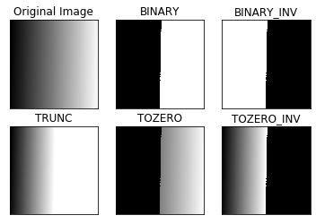

```python
import cv2
import numpy as np
from matplotlib import pyplot as plt

img = cv2.imread('images/gradient.png',0)
ret,thresh1 = cv2.threshold(img,127,255,cv2.THRESH_BINARY)
ret,thresh2 = cv2.threshold(img,127,255,cv2.THRESH_BINARY_INV)
ret,thresh3 = cv2.threshold(img,127,255,cv2.THRESH_TRUNC)
ret,thresh4 = cv2.threshold(img,127,255,cv2.THRESH_TOZERO)
ret,thresh5 = cv2.threshold(img,127,255,cv2.THRESH_TOZERO_INV)

titles = ['Original Image','BINARY','BINARY_INV','TRUNC','TOZERO','TOZERO_INV']
images = [img, thresh1, thresh2, thresh3, thresh4, thresh5]

for i in range(0,6):
    plt.subplot(2,3,i+1)
    plt.imshow(images[i],'gray')
    plt.title(titles[i])
    plt.xticks([])
    plt.yticks([])

plt.show()
```

### 2) `cv2.adaptiveThreshold`

There are two types of adaptive thresholding :

1. `cv2.ADAPTIVE_THRESH_MEAN_C` : threshold value is the mean of neighbourhood area.
2. `cv2.ADAPTIVE_THRESH_GAUSSIAN_C` : threshold value is the weighted sum of neighbourhood values where weights are a gaussian window.

**syntax for adaptive thresholding**  
`cv2.adaptiveThreshold(imgage array, max value, adaptive threshold type, threshold type, block size, constant)`

- Threshold type - The threshold can only be `cv2.THRESH_BINARY` or `cv2.THRESH_BINARY_INV`
- block size - The kernal size use to calculate the mean and the weighted mean (the samller the block size fastert the computation)
- consatnt - The value that is dedcucted from the calculated adaptive thershold

```python
import cv2
import numpy as np
from matplotlib import pyplot as plt

img = cv2.imread('images/sudoku.png',0)
img = cv2.medianBlur(img,5)

ret,th1 = cv2.threshold(img,127, 255, cv2.THRESH_BINARY)
th2 = cv2.adaptiveThreshold(img, 255, cv2.ADAPTIVE_THRESH_MEAN_C, cv2.THRESH_BINARY,5,2)
th3 = cv2.adaptiveThreshold(img, 255, cv2.ADAPTIVE_THRESH_GAUSSIAN_C, cv2.THRESH_BINARY,5,2)

while True:
    cv2.imshow('original', img)
    cv2.imshow('notmal threshold', th1)
    cv2.imshow('adaptive threshold mean', th2)
    cv2.imshow('adaptive threshold Gaussian', th2)

    if cv2.waitKey(50) == ord('q'):
        break

cv2.destroyAllWindows()
```

## Home Work

### 1) Threshold the below image such that the shaded region of the circle becomes black

[figure not shown]

### 2) Threshold the below image such that the text becomes clear

[figure not shown]

# Otsu’s Binarization

To be only done later if required else skip()